# Extensions from LMM

2018-04-13

## You will learn in this session

- how to handle temporal and spatial autocorrelation
- that GLMM are not very difficult if you already know GLM and LMM
- that random effects as well can have non Gaussian distribution
- that there are even more general methods than GLMM out there: HGLM and DHGLM
- how to handle heteroscedasticity

## Temporal autocorrelation

## Temporal autocorrelation in discrete (equaly spaced) time steps

## The `AirPassengers` data

```r
AirPassengers
```

```
##      Jan Feb Mar Apr May Jun Jul Aug Sep Oct Nov Dec
## 1949 112 118 132 129 121 135 148 148 136 119 104 118
## 1950 115 126 141 135 125 149 170 170 158 133 114 140
## 1951 145 150 178 163 172 178 199 199 184 162 146 166
## 1952 171 180 193 181 183 218 230 242 209 191 172 194
## 1953 196 196 236 235 229 243 264 272 237 211 180 201
## 1954 204 188 235 227 234 264 302 293 259 229 203 229
## 1955 242 233 267 269 270 315 364 347 312 274 237 278
## 1956 284 277 317 313 318 374 413 405 355 306 271 306
## 1957 315 301 356 348 355 422 465 467 404 347 305 336
## 1958 340 318 362 348 363 435 491 505 404 359 310 337
## 1959 360 342 406 396 420 472 548 559 463 407 362 405
## 1960 417 391 419 461 472 535 622 606 508 461 390 432
```

## The `AirPassengers` data

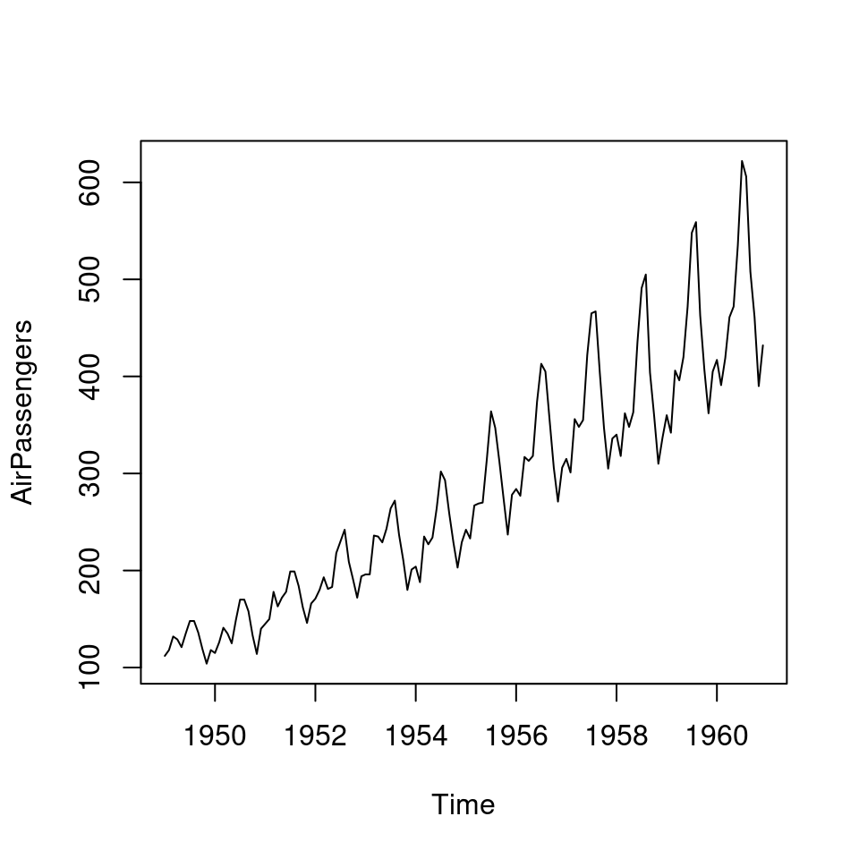

```r
plot(AirPassengers)
```

## Reformating the dataset for the fit

```r
air <- data.frame(passengers = as.numeric(AirPassengers),
                  year = rep(1949:1960, each = 12),
                  month = factor(rep(1:12, 12)))
air
```

```
##     passengers year month
## 1          112 1949     1
## 2          118 1949     2
## 3          132 1949     3
## 4          129 1949     4
## 5          121 1949     5
## 6          135 1949     6
## 7          148 1949     7
## 8          148 1949     8
## 9          136 1949     9
## 10         119 1949    10
## 11         104 1949    11
## 12         118 1949    12
## 13         115 1950     1
## 14         126 1950     2
```

[output cut: 130 more lines]

## Looking at the average trend per year

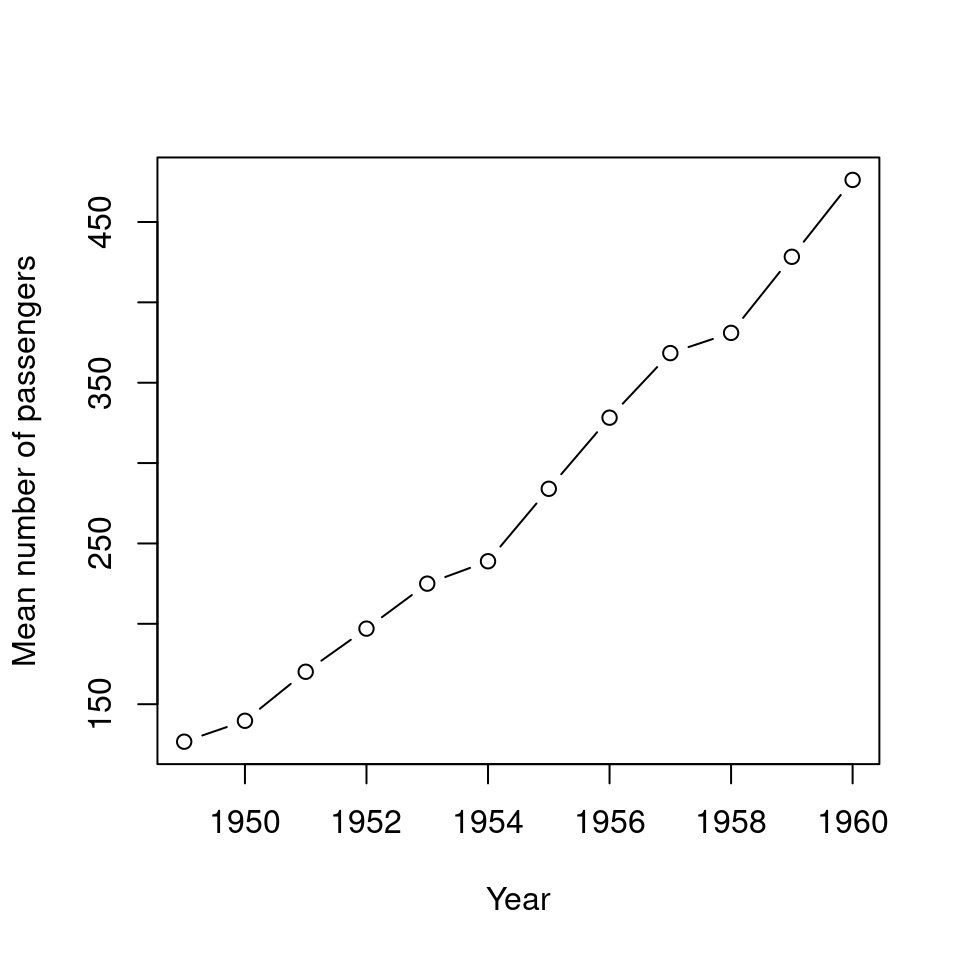

```r
plot(with(air, tapply(passengers, year, mean)) ~ I(1949:1960),
     ylab = "Mean number of passengers", xlab = "Year", type = "b")
```

## Looking at the average trend per month

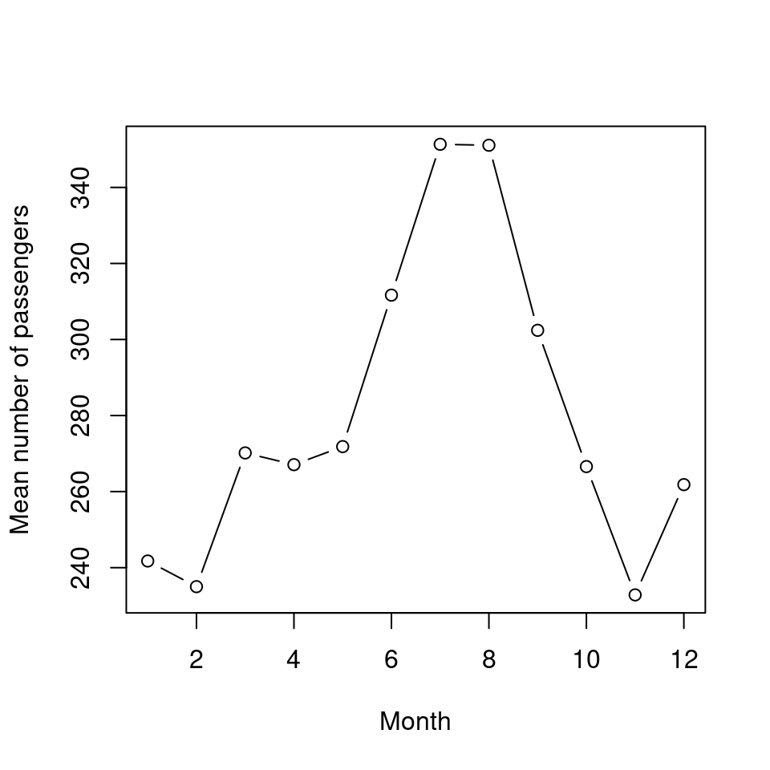

```r
plot(with(air, tapply(passengers, month, mean)) ~ I(1:12),
     ylab = "Mean number of passengers", xlab = "Month", type = "b")
```

## Simple fit

```r
(mod_air <- lm(passengers ~ year * month, data = air))
```

```
##
## Call:
## lm(formula = passengers ~ year * month, data = air)
##
## Coefficients:
##  (Intercept)          year        month2        month3        month4        month5        month6
##   -5.407e+04     2.779e+01     6.356e+03     2.129e+02    -3.118e+03    -7.275e+03    -1.786e+04
##       month7        month8        month9       month10       month11       month12   year:month2
##   -2.994e+04    -2.936e+04    -1.232e+04    -5.237e+03     3.060e+03    -1.094e+03    -3.255e+00
##  year:month3   year:month4   year:month5   year:month6   year:month7   year:month8   year:month9
##   -9.441e-02     1.608e+00     3.738e+00     9.171e+00     1.537e+01     1.508e+01     6.336e+00
## year:month10  year:month11  year:month12
##    2.692e+00    -1.570e+00     5.699e-01
```

## The problem

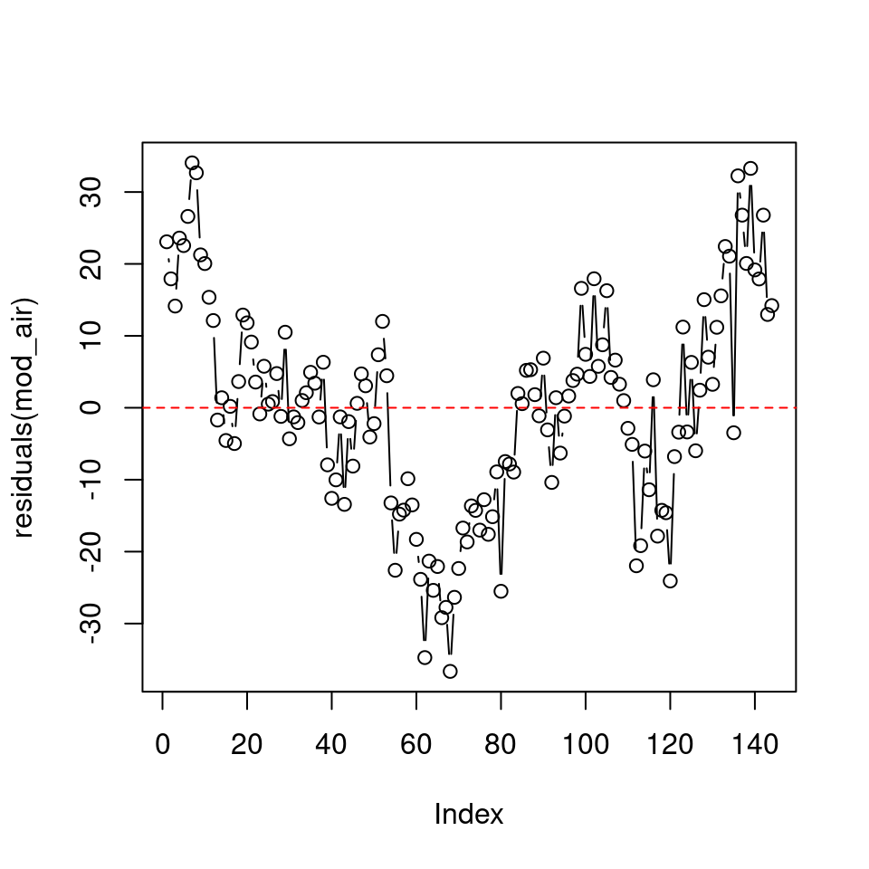

```r
plot(residuals(mod_air), type = "b")
abline(h = 0, lty = 2, col = "red")
```

## The problem

```r
lmtest::dwtest(mod_air)
```

```
##
##  Durbin-Watson test
##
## data:  mod_air
## DW = 0.35903, p-value < 2.2e-16
## alternative hypothesis: true autocorrelation is greater than 0
```

## The problem

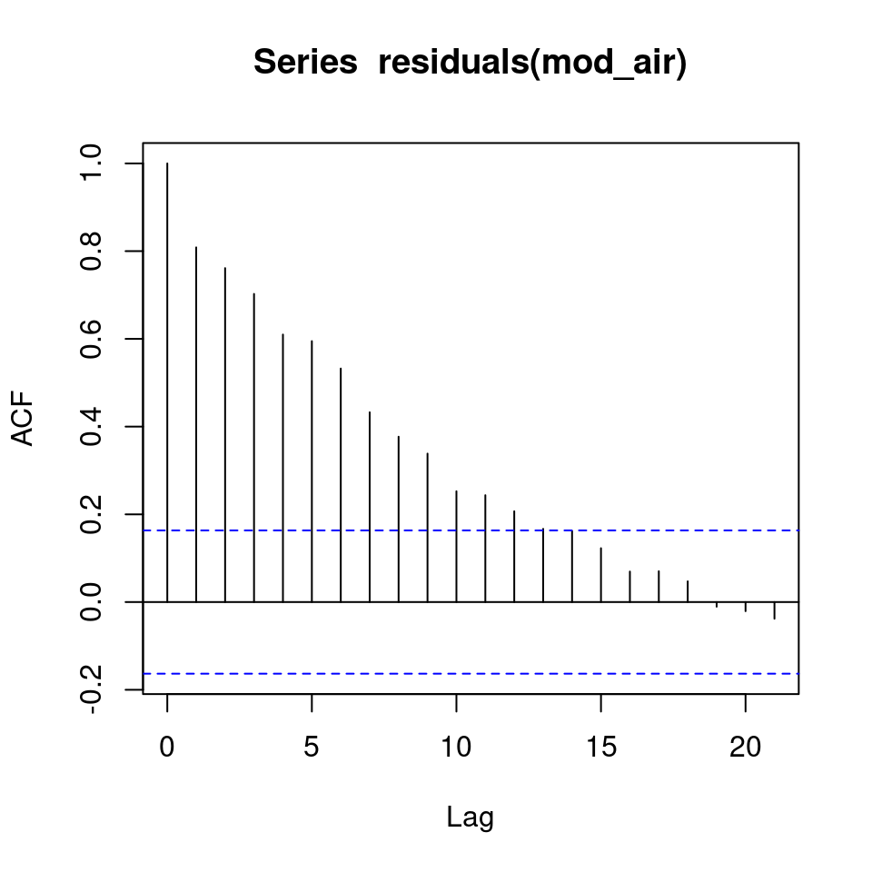

```r
acf(residuals(mod_air))
```

## Solution

```r
library(nlme)
MAR1 <- corAR1(value = 0.5, form = ~ 1|year, fixed = FALSE)
MAR1 <- Initialize(MAR1, data = air)
round(corMatrix(MAR1)[["1950"]], 2)
```

```
##       [,1] [,2] [,3] [,4] [,5] [,6] [,7] [,8] [,9] [,10] [,11] [,12]
##  [1,] 1.00 0.50 0.25 0.13 0.06 0.03 0.02 0.01 0.00  0.00  0.00  0.00
##  [2,] 0.50 1.00 0.50 0.25 0.13 0.06 0.03 0.02 0.01  0.00  0.00  0.00
##  [3,] 0.25 0.50 1.00 0.50 0.25 0.13 0.06 0.03 0.02  0.01  0.00  0.00
##  [4,] 0.13 0.25 0.50 1.00 0.50 0.25 0.13 0.06 0.03  0.02  0.01  0.00
##  [5,] 0.06 0.13 0.25 0.50 1.00 0.50 0.25 0.13 0.06  0.03  0.02  0.01
##  [6,] 0.03 0.06 0.13 0.25 0.50 1.00 0.50 0.25 0.13  0.06  0.03  0.02
##  [7,] 0.02 0.03 0.06 0.13 0.25 0.50 1.00 0.50 0.25  0.13  0.06  0.03
##  [8,] 0.01 0.02 0.03 0.06 0.13 0.25 0.50 1.00 0.50  0.25  0.13  0.06
##  [9,] 0.00 0.01 0.02 0.03 0.06 0.13 0.25 0.50 1.00  0.50  0.25  0.13
## [10,] 0.00 0.00 0.01 0.02 0.03 0.06 0.13 0.25 0.50  1.00  0.50  0.25
## [11,] 0.00 0.00 0.00 0.01 0.02 0.03 0.06 0.13 0.25  0.50  1.00  0.50
## [12,] 0.00 0.00 0.00 0.00 0.01 0.02 0.03 0.06 0.13  0.25  0.50  1.00
```

## Solution

```r
(mod_air2 <- lme(passengers ~ month * year, random = ~ 1 | year, data = air,
                 correlation = MAR1, method = "REML"))
```

```
## Linear mixed-effects model fit by REML
##   Data: air
##   Log-restricted-likelihood: -477.871
##   Fixed: passengers ~ month * year
##   (Intercept)        month2        month3        month4        month5        month6        month7
## -5.406738e+04  6.355626e+03  2.129324e+02 -3.118268e+03 -7.275373e+03 -1.785545e+04 -2.993915e+04
##        month8        month9       month10       month11       month12          year   month2:year
## -2.935851e+04 -1.232239e+04 -5.237282e+03  3.059512e+03 -1.093845e+03  2.778671e+01 -3.255245e+00
##   month3:year   month4:year   month5:year   month6:year   month7:year   month8:year   month9:year
## -9.440559e-02  1.608392e+00  3.737762e+00  9.171329e+00  1.537413e+01  1.507692e+01  6.335664e+00
##  month10:year  month11:year  month12:year
##  2.692308e+00 -1.569930e+00  5.699301e-01
##
## Random effects:
##  Formula: ~1 | year
##         (Intercept) Residual
## StdDev:     13.4979  8.34667
##
## Correlation Structure: AR(1)
##  Formula: ~1 | year
##  Parameter estimate(s):
##       Phi
## 0.3270032
## Number of Observations: 144
## Number of Groups: 12
```

## Alternative code

```r
(mod_air2b <- lme(passengers ~ month * year, random = ~ 1 | year, data = air,
                 correlation = corAR1(form = ~ 1|year), method = "REML"))
```

```
## Linear mixed-effects model fit by REML
##   Data: air
##   Log-restricted-likelihood: -477.871
##   Fixed: passengers ~ month * year
##   (Intercept)        month2        month3        month4        month5        month6        month7
## -5.406738e+04  6.355626e+03  2.129324e+02 -3.118268e+03 -7.275373e+03 -1.785545e+04 -2.993915e+04
##        month8        month9       month10       month11       month12          year   month2:year
## -2.935851e+04 -1.232239e+04 -5.237282e+03  3.059512e+03 -1.093845e+03  2.778671e+01 -3.255245e+00
##   month3:year   month4:year   month5:year   month6:year   month7:year   month8:year   month9:year
## -9.440559e-02  1.608392e+00  3.737762e+00  9.171329e+00  1.537413e+01  1.507692e+01  6.335664e+00
##  month10:year  month11:year  month12:year
##  2.692308e+00 -1.569930e+00  5.699301e-01
##
## Random effects:
##  Formula: ~1 | year
##         (Intercept) Residual
## StdDev:     13.4979 8.346669
##
## Correlation Structure: AR(1)
##  Formula: ~1 | year
##  Parameter estimate(s):
##       Phi
## 0.3270031
## Number of Observations: 144
## Number of Groups: 12
```

## Testing the temporal autocorrelation

```r
mod_air3 <- lme(passengers ~ month * year, random = ~ 1 | year, data = air, method = "REML")
anova(mod_air2, mod_air3)
```

```
##          Model df      AIC      BIC    logLik   Test  L.Ratio p-value
## mod_air2     1 27 1009.742 1085.004 -477.8710
## mod_air3     2 26 1017.362 1089.837 -482.6811 1 vs 2 9.620272  0.0019
```

## Alternative autocorrelation structures

```r
mod_airARMA1 <- update(mod_air2, correlation = corARMA(form = ~ 1 | year, p = 1, q = 0))
mod_airARMA2 <- update(mod_air2, correlation = corARMA(form = ~ 1 | year, p = 4, q = 0))
mod_airARMA3 <- update(mod_air2, correlation = corARMA(form = ~ 1 | year, p = 2, q = 2))

rbind(mod_air2 = AIC(mod_air2),
      mod_airARMA1 = AIC(mod_airARMA1),
      mod_airARMA2 = AIC(mod_airARMA2),
      mod_airARMA3 = AIC(mod_airARMA3))
```

```
##                  [,1]
## mod_air2     1009.742
## mod_airARMA1 1009.742
## mod_airARMA2 1008.911
## mod_airARMA3 1011.174
```

Note: do not compare AICs or likelihoods from `nlme` to those from other packages!

(it seems they have failed to consider a constant term…)

## Fitted values

```r
mod_air4 <- update(mod_air2, correlation = corARMA(form = ~ 1 | year, p = 4, q = 0), method = "ML")
data.for.plot <- expand.grid(month = factor(1:12), year = 1949:1960)
data.for.plot$obs <- air$passengers
data.for.plot$time <- seq(1949, 1960, length = (1960 - 1949 + 1) * 12)
data.for.plot$fit_lm <- predict(mod_air)
data.for.plot$fit_lme <- predict(mod_air4)
```

## Fitted values

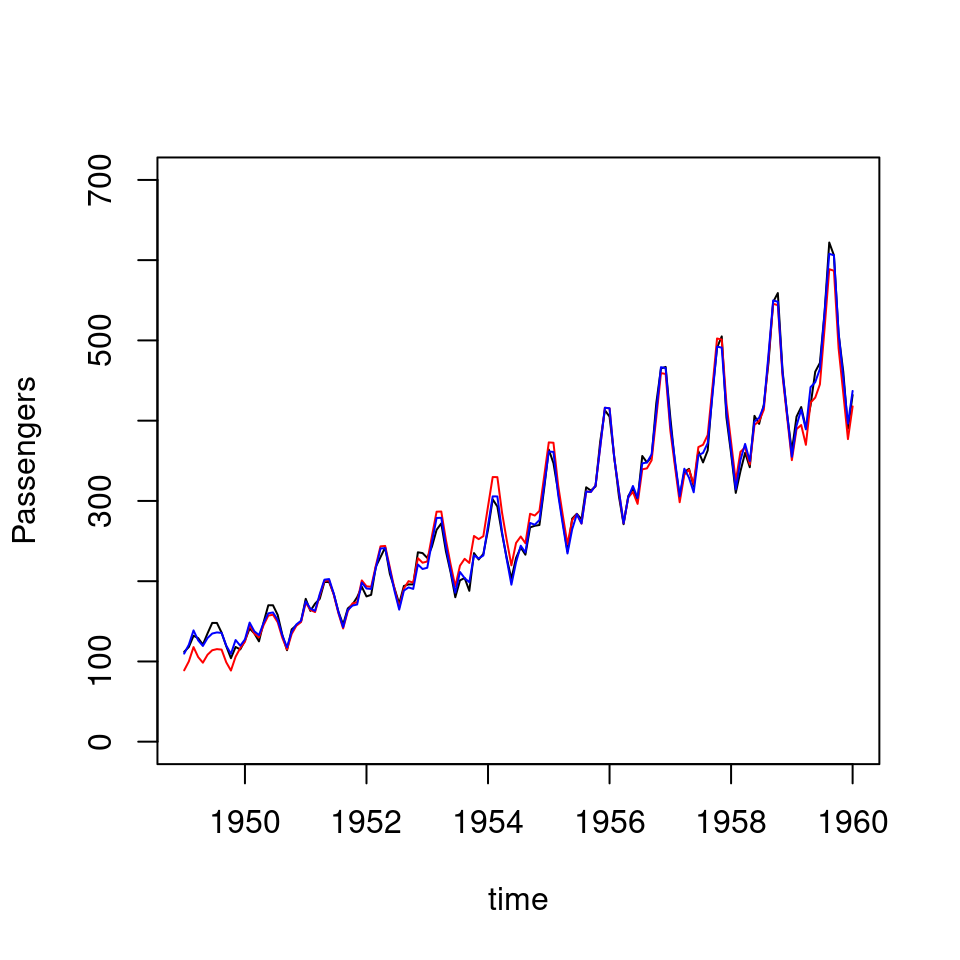

```r
plot(obs ~ time, data = data.for.plot, type = "l", ylim = c(0, 700), ylab = "Passengers")
points(fit_lm ~ time, data = data.for.plot, type = "l", col = "red")
points(fit_lme ~ time, data = data.for.plot, type = "l", col = "blue")
```

## Better, but good enough?

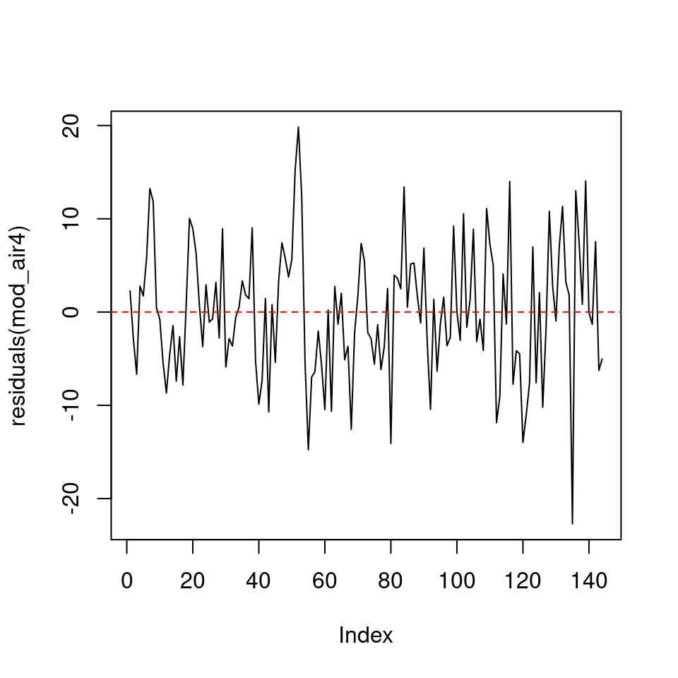

```r
plot(residuals(mod_air4), type = "l")
abline(h = 0, lty = 2, col = "red")
```